# CausalMultiOmics analysis report

Outcome: **died** · generated 2026-08-09 13:22:04

## Main findings

This report summarises the relationships found between the measured variables and the outcome studied. It was produced automatically: every number below comes from the data supplied, and nothing was chosen by hand.

Outcome studied

died

People or samples

687

Variables examined

150

Relationships found

181

Methods used

7

Measured in order

0 of 181

### In short

#### What this report can and cannot tell you

Finding that two things go together is not the same as showing that one causes the other. Two variables can move together because a third thing drives both of them. Ice cream sales and sunburn rise together, but ice cream does not cause sunburn: hot weather causes both.

Agreement between methods does not fix this. If every method is looking at the same data, and something that was never measured is driving both variables, then every method will report the same relationship and every one of them will be misled in the same way. High agreement means the finding is stable, not that it is causal.

## How to read this report

Each relationship gets a score from 0 to 100 called the evidence score. It is built from three separate things, and it helps to keep them apart:

#### Size

How big the relationship is. A large value means that when one variable changes, the other changes a lot.

#### Precision

How sure we are of the number itself. This grows with the number of samples and shrinks when the estimate is noisy.

#### Agreement

How many of the analysis methods saw the same thing. Several methods were run on the same data; this counts how many agreed.

#### What this report can and cannot tell you

Finding that two things go together is not the same as showing that one causes the other. Two variables can move together because a third thing drives both of them. Ice cream sales and sunburn rise together, but ice cream does not cause sunburn: hot weather causes both.

Agreement between methods does not fix this. If every method is looking at the same data, and something that was never measured is driving both variables, then every method will report the same relationship and every one of them will be misled in the same way. High agreement means the finding is stable, not that it is causal.

Because of that, every relationship below is labelled with how much can be claimed about cause:

#### Observed together

The two were seen to move together and nothing else was taken into account. This is the weakest claim.

#### Other factors accounted for

Known factors were subtracted out. This is stronger, but only for the factors that were actually measured. Anything not measured is still unaccounted for.

#### Measured in order

The first variable was measured before the second. That rules out the relationship running backwards, which is real progress, but it still does not rule out a third factor driving both.

#### Instrumented

A special kind of variable was used that, under strong assumptions, does support a causal reading.

#### Does one number describe everybody?

Every figure in this report is an average over the people who were measured, and an average says nothing about whether they resemble each other. The same number can mean the relationship holds in everyone, or that it is strong in a tenth of them and absent in the rest. Those are different findings: the first is about the group, the second is about ten people nobody has identified.

Nothing was named as a possible modifier, so no subgroup was tested directly. Passing `heterogeneity =` a metadata column asks whether each relationship differs across it.

#### Measured values and filled-in values

Some of the variables here arrived with gaps. Rather than throw those people away, preprocessing estimated what the missing numbers probably were. That is standard practice and usually the right call, but it has a consequence nothing downstream can see: once a gap is filled, no model can tell a measurement from an estimate, and the confidence intervals come out exactly as narrow as if every value had been real.

**163** of the relationships in this report involve a variable that was partly filled in. Their scores were scaled down in proportion to how much was filled and how much the filling method preserves — the most affected keeps **81%** of what its statistics alone would earn. Nothing else about them was changed.

Each was also refitted using only the people whose value was actually measured. **2** of **20** changed direction. A relationship that reverses when the estimated values are removed was produced by the filling, not found in the data.

Sample size is a separate matter and is already in the precision score. This is only about values that were reconstructed.

#### No causal diagram was supplied

Every label above was inferred from the shape of the study alone: what was measured, when, and what was adjusted for. That tells you a model controlled for something; it cannot tell you whether the right something was controlled for.

If you are willing to commit to a diagram of what causes what, pass it as `analyze(..., dag = )` and each relationship will be checked against it. Adjusting for a variable that sits between the exposure and the outcome, or for one the outcome itself causes, makes an estimate worse rather than better, and nothing in the data will reveal that.

## Main findings

Relationships with **died**, strongest evidence first.

Higher any_ht goes together with higher diedOther factors accounted for

27

**0.42**Size

**0.79**Precision

**1.00**Agreement

**4**method(s) agreed

Found by: logistic regression; elastic net; random forest importance; Bayesian network (hill climbing)

#### This number describes a few people, not the group

Removing the **15** most influential people — **2%** of everyone measured — halves this relationship. A relationship that holds across a group does not behave like that: removing a handful of people barely moves an average. This one is carried by those few.

#### Part of this was filled in, not measured

- 0% of this variable was missing and was filled in by the commonest value in the column.
- 0% of this variable was missing and was filled in by k-nearest-neighbours, borrowing from correlated features.
- 3% of this variable was missing and was filled in by k-nearest-neighbours, borrowing from correlated features.
- 7% of this variable was missing and was filled in by k-nearest-neighbours, borrowing from correlated features.
- 4% of this variable was missing and was filled in by k-nearest-neighbours, borrowing from correlated features.
- 8% of this variable was missing and was filled in by the commonest value in the column.
- 9% of this variable was missing and was filled in by the commonest value in the column.
- 1% of this variable was missing and was filled in by k-nearest-neighbours, borrowing from correlated features.
- 21% of this variable was missing and was filled in by k-nearest-neighbours, borrowing from correlated features.
- 29% of this variable was missing and was filled in by k-nearest-neighbours, borrowing from correlated features.
- 6% of this variable was missing and was filled in by k-nearest-neighbours, borrowing from correlated features.
- 1% of this variable was missing and was filled in by the column median.
- 31% of this variable was missing and was filled in by k-nearest-neighbours, borrowing from correlated features.
- 5% of this variable was missing and was filled in by k-nearest-neighbours, borrowing from correlated features.
- 9% of this variable was missing and was filled in by k-nearest-neighbours, borrowing from correlated features.
- 19% of this variable was missing and was filled in by k-nearest-neighbours, borrowing from correlated features.
- 1% of this variable was missing and was filled in by the commonest value in the column.
- 7% of this variable was missing and was filled in by the commonest value in the column.
- 29% of this variable was missing and was filled in by the commonest value in the column.
- 2% of this variable was missing and was filled in by k-nearest-neighbours, borrowing from correlated features.
- 8% of this variable was missing and was filled in by k-nearest-neighbours, borrowing from correlated features.

The score for this relationship was scaled down to **81%** of what the statistics alone would give it, set by **ever_osteo_arthritis**.

Refitting on the **683** people whose value was actually measured gives **0.7454**, against **0.7465** overall. Same direction, so this relationship is in the measured data and not an artefact of the filling.

**What each method found on its own**

Each row is one method working alone, before anything was combined. The third column says what kind of number it is: a log hazard ratio and a drop in prediction accuracy are not the same measurement and cannot be averaged together. Only rows marked **combined** went into the headline estimate; the rest still count towards agreement, because two methods pointing the same way is informative even when their magnitudes are not.

Headline estimate: **log odds ratio**, pooled from 1 observation(s). Left out: penalised coefficient, permutation importance, network arc strength.

| Method | Kind of evidence | What it measured | Combined | Estimate | 95% CI | p-value | FDR | Samples | Agrees |
| --- | --- | --- | --- | --- | --- | --- | --- | --- | --- |
| logistic regression | associational | log odds ratio | yes | 0.7465 | 0.312 to 1.181 | 0.00076 | 0.012 | 687 | yes |
| elastic net | predictive | penalised coefficient | no | 0.4927 | not reported | not reported | not reported | 687 | yes |
| random forest importance | predictive | permutation importance | no | 0.0039 | not reported | not reported | not reported | 687 | yes |
| Bayesian network (hill climbing) | associational | network arc strength | no | 15.0697 | not reported | not reported | not reported | 687 | yes |

#### What these methods are

#### logistic regression

Fits a straight line between the variable and the outcome, after subtracting the effect of any factors you asked it to account for.

**What it cannot tell you.** It cannot tell which one came first, and it can only account for factors that were actually measured.

#### elastic net

Fits every variable at once and shrinks the useless ones to exactly zero, so what survives is a short list that predicts the outcome together.

**What it cannot tell you.** When two variables carry the same information it keeps one and drops the other, so being dropped is not evidence of having no effect.

#### random forest importance

Builds hundreds of decision trees and measures how much worse the predictions get when one variable is scrambled. A big drop means the variable carried real information.

**What it cannot tell you.** It measures usefulness for prediction, not the size or the direction of an effect. Something downstream of the outcome predicts it beautifully.

#### Bayesian network (hill climbing)

Searches for a network of arrows that explains the observed pattern of correlations with as few connections as possible.

**What it cannot tell you.** Several different arrangements of arrows explain the same data equally well, so the direction it picks is often one of many that fit.

**What would settle this**

Each of these follows from a specific weakness in this relationship rather than from general caution, so they are in the order the evidence puts them.

1. Measure a confounder of any_ht and died. To erase this it would have to be associated with both at a risk ratio of at least 3.6; anything weaker leaves the relationship standing.
2. Measure any_ht before died in the same people. Nothing in this data establishes which came first, and the reverse direction fits it equally well.
3. Replicate in a cohort collected independently. Here the estimate is halved by removing 15 people, so it may describe them rather than the population.
4. Measure ever_osteo_arthritis in the people whose value was filled in. Part of this estimate rests on numbers that were reconstructed rather than observed.

Higher DR1TS120 goes together with lower diedOther factors accounted for

18

**0.24**Size

**0.73**Precision

**1.00**Agreement

**1**method(s) agreed

Found by: logistic regression

#### This number describes a few people, not the group

Removing the **10** most influential people — **1%** of everyone measured — halves this relationship. A relationship that holds across a group does not behave like that: removing a handful of people barely moves an average. This one is carried by those few.

#### Part of this was filled in, not measured

- 4% of this variable was missing and was filled in by k-nearest-neighbours, borrowing from correlated features.

The score for this relationship was scaled down to **99%** of what the statistics alone would give it, set by **DR1TS120**.

**What each method found on its own**

Each row is one method working alone, before anything was combined. The third column says what kind of number it is: a log hazard ratio and a drop in prediction accuracy are not the same measurement and cannot be averaged together. Only rows marked **combined** went into the headline estimate; the rest still count towards agreement, because two methods pointing the same way is informative even when their magnitudes are not.

Headline estimate: **log odds ratio**, pooled from 1 observation(s).

| Method | Kind of evidence | What it measured | Combined | Estimate | 95% CI | p-value | FDR | Samples | Agrees |
| --- | --- | --- | --- | --- | --- | --- | --- | --- | --- |
| logistic regression | associational | log odds ratio | yes | -0.3174 | -0.581 to -0.053 | 0.018 | 0.11 | 687 | yes |

#### What these methods are

#### logistic regression

Fits a straight line between the variable and the outcome, after subtracting the effect of any factors you asked it to account for.

**What it cannot tell you.** It cannot tell which one came first, and it can only account for factors that were actually measured.

**What would settle this**

Each of these follows from a specific weakness in this relationship rather than from general caution, so they are in the order the evidence puts them.

1. Measure a confounder of DR1TS120 and died. To erase this it would have to be associated with both at a risk ratio of at least 2.1; anything weaker leaves the relationship standing.
2. Measure DR1TS120 before died in the same people. Nothing in this data establishes which came first, and the reverse direction fits it equally well.
3. Replicate in a cohort collected independently. Here the estimate is halved by removing 10 people, so it may describe them rather than the population.
4. Measure DR1TS120 in the people whose value was filled in. Part of this estimate rests on numbers that were reconstructed rather than observed.
5. Separate DR1TS120 from the 5 other variables it moves with. In this data they cannot be told apart, so the effect may belong to any of them or to whatever drives all of them.

Higher LBXHCY goes together with higher diedOther factors accounted for

14

**0.29**Size

**0.78**Precision

**0.74**Agreement

**4**method(s) agreed

Found by: logistic regression; elastic net; random forest importance; Bayesian network (hill climbing)

Methods reporting the opposite direction: structural equation model

#### This number describes a few people, not the group

Removing the **10** most influential people — **1%** of everyone measured — halves this relationship. A relationship that holds across a group does not behave like that: removing a handful of people barely moves an average. This one is carried by those few.

- 0% of this variable was missing and was filled in by k-nearest-neighbours, borrowing from correlated features.
- 3% of this variable was missing and was filled in by k-nearest-neighbours, borrowing from correlated features.
- 7% of this variable was missing and was filled in by k-nearest-neighbours, borrowing from correlated features.
- 4% of this variable was missing and was filled in by k-nearest-neighbours, borrowing from correlated features.
- 0% of this variable was missing and was filled in by the commonest value in the column.
- 8% of this variable was missing and was filled in by the commonest value in the column.
- 9% of this variable was missing and was filled in by the commonest value in the column.
- 1% of this variable was missing and was filled in by k-nearest-neighbours, borrowing from correlated features.
- 21% of this variable was missing and was filled in by k-nearest-neighbours, borrowing from correlated features.
- 29% of this variable was missing and was filled in by k-nearest-neighbours, borrowing from correlated features.
- 6% of this variable was missing and was filled in by k-nearest-neighbours, borrowing from correlated features.
- 1% of this variable was missing and was filled in by the column median.
- 31% of this variable was missing and was filled in by k-nearest-neighbours, borrowing from correlated features.
- 5% of this variable was missing and was filled in by k-nearest-neighbours, borrowing from correlated features.
- 9% of this variable was missing and was filled in by k-nearest-neighbours, borrowing from correlated features.
- 19% of this variable was missing and was filled in by k-nearest-neighbours, borrowing from correlated features.
- 1% of this variable was missing and was filled in by the commonest value in the column.
- 7% of this variable was missing and was filled in by the commonest value in the column.
- 29% of this variable was missing and was filled in by the commonest value in the column.
- 2% of this variable was missing and was filled in by k-nearest-neighbours, borrowing from correlated features.
- 8% of this variable was missing and was filled in by k-nearest-neighbours, borrowing from correlated features.

The score for this relationship was scaled down to **81%** of what the statistics alone would give it, set by **ever_osteo_arthritis**.

**What each method found on its own**

Each row is one method working alone, before anything was combined. The third column says what kind of number it is: a log hazard ratio and a drop in prediction accuracy are not the same measurement and cannot be averaged together. Only rows marked **combined** went into the headline estimate; the rest still count towards agreement, because two methods pointing the same way is informative even when their magnitudes are not.

| Method | Kind of evidence | What it measured | Combined | Estimate | 95% CI | p-value | FDR | Samples | Agrees |
| --- | --- | --- | --- | --- | --- | --- | --- | --- | --- |
| logistic regression | associational | log odds ratio | yes | 0.4299 | 0.159 to 0.701 | 0.0018 | 0.023 | 687 | yes |
| elastic net | predictive | penalised coefficient | no | 0.2385 | not reported | not reported | not reported | 687 | yes |
| random forest importance | predictive | permutation importance | no | 0.0086 | not reported | not reported | not reported | 687 | yes |
| Bayesian network (hill climbing) | associational | network arc strength | no | 25.6532 | not reported | not reported | not reported | 687 | yes |
| structural equation model | associational | regression coefficient | yes | 0.0000 | not reported | not reported | not reported | 687 | no |

#### What these methods are

#### logistic regression

Fits a straight line between the variable and the outcome, after subtracting the effect of any factors you asked it to account for.

**What it cannot tell you.** It cannot tell which one came first, and it can only account for factors that were actually measured.

#### elastic net

Fits every variable at once and shrinks the useless ones to exactly zero, so what survives is a short list that predicts the outcome together.

**What it cannot tell you.** When two variables carry the same information it keeps one and drops the other, so being dropped is not evidence of having no effect.

#### random forest importance

Builds hundreds of decision trees and measures how much worse the predictions get when one variable is scrambled. A big drop means the variable carried real information.

**What it cannot tell you.** It measures usefulness for prediction, not the size or the direction of an effect. Something downstream of the outcome predicts it beautifully.

#### Bayesian network (hill climbing)

Searches for a network of arrows that explains the observed pattern of correlations with as few connections as possible.

**What it cannot tell you.** Several different arrangements of arrows explain the same data equally well, so the direction it picks is often one of many that fit.

#### structural equation model

Fits all the candidate variables against the outcome simultaneously, so each estimate is adjusted for the others.

**What it cannot tell you.** The structure it fits was written automatically, not derived from biology. It is a multivariable regression, despite the name.

**What would settle this**

Higher DR1TFIBE goes together with lower diedOther factors accounted for

13

**0.19**Size

**0.82**Precision

**1.00**Agreement

**2**method(s) agreed

Found by: logistic regression; random forest importance

#### This number describes a few people, not the group

Removing the **27** most influential people — **4%** of everyone measured — halves this relationship. A relationship that holds across a group does not behave like that: removing a handful of people barely moves an average. This one is carried by those few.

#### Part of this was filled in, not measured

- 4% of this variable was missing and was filled in by k-nearest-neighbours, borrowing from correlated features.
- 0% of this variable was missing and was filled in by k-nearest-neighbours, borrowing from correlated features.
- 3% of this variable was missing and was filled in by k-nearest-neighbours, borrowing from correlated features.
- 1% of this variable was missing and was filled in by k-nearest-neighbours, borrowing from correlated features.
- 29% of this variable was missing and was filled in by k-nearest-neighbours, borrowing from correlated features.
- 6% of this variable was missing and was filled in by k-nearest-neighbours, borrowing from correlated features.
- 1% of this variable was missing and was filled in by the column median.
- 31% of this variable was missing and was filled in by k-nearest-neighbours, borrowing from correlated features.
- 7% of this variable was missing and was filled in by k-nearest-neighbours, borrowing from correlated features.
- 5% of this variable was missing and was filled in by k-nearest-neighbours, borrowing from correlated features.
- 9% of this variable was missing and was filled in by k-nearest-neighbours, borrowing from correlated features.
- 19% of this variable was missing and was filled in by k-nearest-neighbours, borrowing from correlated features.
- 0% of this variable was missing and was filled in by the commonest value in the column.
- 1% of this variable was missing and was filled in by the commonest value in the column.
- 8% of this variable was missing and was filled in by the commonest value in the column.
- 7% of this variable was missing and was filled in by the commonest value in the column.
- 9% of this variable was missing and was filled in by the commonest value in the column.
- 29% of this variable was missing and was filled in by the commonest value in the column.
- 21% of this variable was missing and was filled in by k-nearest-neighbours, borrowing from correlated features.
- 2% of this variable was missing and was filled in by k-nearest-neighbours, borrowing from correlated features.
- 8% of this variable was missing and was filled in by k-nearest-neighbours, borrowing from correlated features.

The score for this relationship was scaled down to **81%** of what the statistics alone would give it, set by **ever_osteo_arthritis**.

**What each method found on its own**

Each row is one method working alone, before anything was combined. The third column says what kind of number it is: a log hazard ratio and a drop in prediction accuracy are not the same measurement and cannot be averaged together. Only rows marked **combined** went into the headline estimate; the rest still count towards agreement, because two methods pointing the same way is informative even when their magnitudes are not.

Headline estimate: **log odds ratio**, pooled from 1 observation(s). Left out: permutation importance.

| Method | Kind of evidence | What it measured | Combined | Estimate | 95% CI | p-value | FDR | Samples | Agrees |
| --- | --- | --- | --- | --- | --- | --- | --- | --- | --- |
| logistic regression | associational | log odds ratio | yes | -0.6088 | -0.885 to -0.332 | 1.6e-05 | 0.00048 | 687 | yes |
| random forest importance | predictive | permutation importance | no | -0.0006 | not reported | not reported | not reported | 687 | yes |

#### What these methods are

#### logistic regression

Fits a straight line between the variable and the outcome, after subtracting the effect of any factors you asked it to account for.

**What it cannot tell you.** It cannot tell which one came first, and it can only account for factors that were actually measured.

#### random forest importance

Builds hundreds of decision trees and measures how much worse the predictions get when one variable is scrambled. A big drop means the variable carried real information.

**What it cannot tell you.** It measures usefulness for prediction, not the size or the direction of an effect. Something downstream of the outcome predicts it beautifully.

**What would settle this**

Each of these follows from a specific weakness in this relationship rather than from general caution, so they are in the order the evidence puts them.

1. Measure a confounder of DR1TFIBE and died. To erase this it would have to be associated with both at a risk ratio of at least 3.1; anything weaker leaves the relationship standing.
2. Measure DR1TFIBE before died in the same people. Nothing in this data establishes which came first, and the reverse direction fits it equally well.
3. Replicate in a cohort collected independently. Here the estimate is halved by removing 27 people, so it may describe them rather than the population.
4. Measure ever_osteo_arthritis in the people whose value was filled in. Part of this estimate rests on numbers that were reconstructed rather than observed.
5. Separate DR1TFIBE from the 28 other variables it moves with. In this data they cannot be told apart, so the effect may belong to any of them or to whatever drives all of them.

Higher LBXSTP goes together with higher diedOther factors accounted for

13

**0.18**Size

**0.71**Precision

**1.00**Agreement

**1**method(s) agreed

Found by: logistic regression

#### This number describes a few people, not the group

Removing the **7** most influential people — **1%** of everyone measured — halves this relationship. A relationship that holds across a group does not behave like that: removing a handful of people barely moves an average. This one is carried by those few.

**What each method found on its own**

Each row is one method working alone, before anything was combined. The third column says what kind of number it is: a log hazard ratio and a drop in prediction accuracy are not the same measurement and cannot be averaged together. Only rows marked **combined** went into the headline estimate; the rest still count towards agreement, because two methods pointing the same way is informative even when their magnitudes are not.

Headline estimate: **log odds ratio**, pooled from 1 observation(s).

| Method | Kind of evidence | What it measured | Combined | Estimate | 95% CI | p-value | FDR | Samples | Agrees |
| --- | --- | --- | --- | --- | --- | --- | --- | --- | --- |
| logistic regression | associational | log odds ratio | yes | 0.2261 | 0.014 to 0.438 | 0.037 | 0.15 | 687 | yes |

#### What these methods are

#### logistic regression

Fits a straight line between the variable and the outcome, after subtracting the effect of any factors you asked it to account for.

**What it cannot tell you.** It cannot tell which one came first, and it can only account for factors that were actually measured.

**What would settle this**

Each of these follows from a specific weakness in this relationship rather than from general caution, so they are in the order the evidence puts them.

1. Measure a confounder of LBXSTP and died. To erase this it would have to be associated with both at a risk ratio of at least 1.8; anything weaker leaves the relationship standing.
2. Measure LBXSTP before died in the same people. Nothing in this data establishes which came first, and the reverse direction fits it equally well.
3. Replicate in a cohort collected independently. Here the estimate is halved by removing 7 people, so it may describe them rather than the population.

Higher LBXBAP goes together with higher diedOther factors accounted for

12

**0.17**Size

**0.68**Precision

**1.00**Agreement

**1**method(s) agreed

Found by: logistic regression

#### Part of this was filled in, not measured

- 0% of this variable was missing and was filled in by k-nearest-neighbours, borrowing from correlated features.

The score for this relationship was scaled down to **100%** of what the statistics alone would give it, set by **LBXBAP**.

Refitting on the **686** people whose value was actually measured gives **0.2042**, against **0.2038** overall. Same direction, so this relationship is in the measured data and not an artefact of the filling.

**What each method found on its own**

Each row is one method working alone, before anything was combined. The third column says what kind of number it is: a log hazard ratio and a drop in prediction accuracy are not the same measurement and cannot be averaged together. Only rows marked **combined** went into the headline estimate; the rest still count towards agreement, because two methods pointing the same way is informative even when their magnitudes are not.

Headline estimate: **log odds ratio**, pooled from 1 observation(s).

| Method | Kind of evidence | What it measured | Combined | Estimate | 95% CI | p-value | FDR | Samples | Agrees |
| --- | --- | --- | --- | --- | --- | --- | --- | --- | --- |
| logistic regression | associational | log odds ratio | yes | 0.2038 | -0.015 to 0.423 | 0.068 | 0.21 | 687 | yes |

#### What these methods are

#### logistic regression

Fits a straight line between the variable and the outcome, after subtracting the effect of any factors you asked it to account for.

**What it cannot tell you.** It cannot tell which one came first, and it can only account for factors that were actually measured.

**What would settle this**

Each of these follows from a specific weakness in this relationship rather than from general caution, so they are in the order the evidence puts them.

1. Measure a confounder of LBXBAP and died. To erase this it would have to be associated with both at a risk ratio of at least 1.8; anything weaker leaves the relationship standing.
2. Measure LBXBAP before died in the same people. Nothing in this data establishes which came first, and the reverse direction fits it equally well.
3. Measure LBXBAP in the people whose value was filled in. Part of this estimate rests on numbers that were reconstructed rather than observed.

Higher DR1TCALC goes together with lower diedOther factors accounted for

11

**0.18**Size

**0.65**Precision

**1.00**Agreement

**1**method(s) agreed

Found by: logistic regression

#### Part of this was filled in, not measured

- 4% of this variable was missing and was filled in by k-nearest-neighbours, borrowing from correlated features.

The score for this relationship was scaled down to **99%** of what the statistics alone would give it, set by **DR1TCALC**.

**What each method found on its own**

Each row is one method working alone, before anything was combined. The third column says what kind of number it is: a log hazard ratio and a drop in prediction accuracy are not the same measurement and cannot be averaged together. Only rows marked **combined** went into the headline estimate; the rest still count towards agreement, because two methods pointing the same way is informative even when their magnitudes are not.

Headline estimate: **log odds ratio**, pooled from 1 observation(s).

| Method | Kind of evidence | What it measured | Combined | Estimate | 95% CI | p-value | FDR | Samples | Agrees |
| --- | --- | --- | --- | --- | --- | --- | --- | --- | --- |
| logistic regression | associational | log odds ratio | yes | -0.2176 | -0.489 to 0.053 | 0.12 | 0.27 | 687 | yes |

#### What these methods are

#### logistic regression

Fits a straight line between the variable and the outcome, after subtracting the effect of any factors you asked it to account for.

**What it cannot tell you.** It cannot tell which one came first, and it can only account for factors that were actually measured.

**What would settle this**

Each of these follows from a specific weakness in this relationship rather than from general caution, so they are in the order the evidence puts them.

1. Measure a confounder of DR1TCALC and died. To erase this it would have to be associated with both at a risk ratio of at least 1.8; anything weaker leaves the relationship standing.
2. Measure DR1TCALC before died in the same people. Nothing in this data establishes which came first, and the reverse direction fits it equally well.
3. Measure DR1TCALC in the people whose value was filled in. Part of this estimate rests on numbers that were reconstructed rather than observed.
4. Separate DR1TCALC from the 28 other variables it moves with. In this data they cannot be told apart, so the effect may belong to any of them or to whatever drives all of them.

Higher DR1TVB1 goes together with lower diedOther factors accounted for

10

**0.15**Size

**0.79**Precision

**1.00**Agreement

**2**method(s) agreed

Found by: logistic regression; random forest importance

#### This number describes a few people, not the group

Removing the **16** most influential people — **2%** of everyone measured — halves this relationship. A relationship that holds across a group does not behave like that: removing a handful of people barely moves an average. This one is carried by those few.

#### Part of this was filled in, not measured

- 4% of this variable was missing and was filled in by k-nearest-neighbours, borrowing from correlated features.
- 0% of this variable was missing and was filled in by k-nearest-neighbours, borrowing from correlated features.
- 3% of this variable was missing and was filled in by k-nearest-neighbours, borrowing from correlated features.
- 1% of this variable was missing and was filled in by k-nearest-neighbours, borrowing from correlated features.
- 29% of this variable was missing and was filled in by k-nearest-neighbours, borrowing from correlated features.
- 6% of this variable was missing and was filled in by k-nearest-neighbours, borrowing from correlated features.
- 1% of this variable was missing and was filled in by the column median.
- 31% of this variable was missing and was filled in by k-nearest-neighbours, borrowing from correlated features.
- 7% of this variable was missing and was filled in by k-nearest-neighbours, borrowing from correlated features.
- 5% of this variable was missing and was filled in by k-nearest-neighbours, borrowing from correlated features.
- 9% of this variable was missing and was filled in by k-nearest-neighbours, borrowing from correlated features.
- 19% of this variable was missing and was filled in by k-nearest-neighbours, borrowing from correlated features.
- 0% of this variable was missing and was filled in by the commonest value in the column.
- 1% of this variable was missing and was filled in by the commonest value in the column.
- 8% of this variable was missing and was filled in by the commonest value in the column.
- 7% of this variable was missing and was filled in by the commonest value in the column.
- 9% of this variable was missing and was filled in by the commonest value in the column.
- 29% of this variable was missing and was filled in by the commonest value in the column.
- 21% of this variable was missing and was filled in by k-nearest-neighbours, borrowing from correlated features.
- 2% of this variable was missing and was filled in by k-nearest-neighbours, borrowing from correlated features.
- 8% of this variable was missing and was filled in by k-nearest-neighbours, borrowing from correlated features.

The score for this relationship was scaled down to **81%** of what the statistics alone would give it, set by **ever_osteo_arthritis**.

**What each method found on its own**

Each row is one method working alone, before anything was combined. The third column says what kind of number it is: a log hazard ratio and a drop in prediction accuracy are not the same measurement and cannot be averaged together. Only rows marked **combined** went into the headline estimate; the rest still count towards agreement, because two methods pointing the same way is informative even when their magnitudes are not.

Headline estimate: **log odds ratio**, pooled from 1 observation(s). Left out: permutation importance.

| Method | Kind of evidence | What it measured | Combined | Estimate | 95% CI | p-value | FDR | Samples | Agrees |
| --- | --- | --- | --- | --- | --- | --- | --- | --- | --- |
| logistic regression | associational | log odds ratio | yes | -0.4405 | -0.714 to -0.167 | 0.0016 | 0.022 | 687 | yes |
| random forest importance | predictive | permutation importance | no | -0.0003 | not reported | not reported | not reported | 687 | yes |

#### What these methods are

#### logistic regression

Fits a straight line between the variable and the outcome, after subtracting the effect of any factors you asked it to account for.

**What it cannot tell you.** It cannot tell which one came first, and it can only account for factors that were actually measured.

#### random forest importance

Builds hundreds of decision trees and measures how much worse the predictions get when one variable is scrambled. A big drop means the variable carried real information.

**What it cannot tell you.** It measures usefulness for prediction, not the size or the direction of an effect. Something downstream of the outcome predicts it beautifully.

**What would settle this**

Each of these follows from a specific weakness in this relationship rather than from general caution, so they are in the order the evidence puts them.

1. Measure a confounder of DR1TVB1 and died. To erase this it would have to be associated with both at a risk ratio of at least 2.5; anything weaker leaves the relationship standing.
2. Measure DR1TVB1 before died in the same people. Nothing in this data establishes which came first, and the reverse direction fits it equally well.
3. Replicate in a cohort collected independently. Here the estimate is halved by removing 16 people, so it may describe them rather than the population.
4. Measure ever_osteo_arthritis in the people whose value was filled in. Part of this estimate rests on numbers that were reconstructed rather than observed.
5. Separate DR1TVB1 from the 28 other variables it moves with. In this data they cannot be told apart, so the effect may belong to any of them or to whatever drives all of them.

Higher any_diabetes goes together with higher diedOther factors accounted for

10

**0.17**Size

**0.70**Precision

**1.00**Agreement

**2**method(s) agreed

Found by: logistic regression; random forest importance

#### Part of this was filled in, not measured

- 1% of this variable was missing and was filled in by the commonest value in the column.
- 0% of this variable was missing and was filled in by k-nearest-neighbours, borrowing from correlated features.
- 3% of this variable was missing and was filled in by k-nearest-neighbours, borrowing from correlated features.
- 1% of this variable was missing and was filled in by k-nearest-neighbours, borrowing from correlated features.
- 29% of this variable was missing and was filled in by k-nearest-neighbours, borrowing from correlated features.
- 6% of this variable was missing and was filled in by k-nearest-neighbours, borrowing from correlated features.
- 1% of this variable was missing and was filled in by the column median.
- 31% of this variable was missing and was filled in by k-nearest-neighbours, borrowing from correlated features.
- 7% of this variable was missing and was filled in by k-nearest-neighbours, borrowing from correlated features.
- 4% of this variable was missing and was filled in by k-nearest-neighbours, borrowing from correlated features.
- 5% of this variable was missing and was filled in by k-nearest-neighbours, borrowing from correlated features.
- 9% of this variable was missing and was filled in by k-nearest-neighbours, borrowing from correlated features.
- 19% of this variable was missing and was filled in by k-nearest-neighbours, borrowing from correlated features.
- 0% of this variable was missing and was filled in by the commonest value in the column.
- 8% of this variable was missing and was filled in by the commonest value in the column.
- 7% of this variable was missing and was filled in by the commonest value in the column.
- 9% of this variable was missing and was filled in by the commonest value in the column.
- 29% of this variable was missing and was filled in by the commonest value in the column.
- 21% of this variable was missing and was filled in by k-nearest-neighbours, borrowing from correlated features.
- 2% of this variable was missing and was filled in by k-nearest-neighbours, borrowing from correlated features.
- 8% of this variable was missing and was filled in by k-nearest-neighbours, borrowing from correlated features.

The score for this relationship was scaled down to **81%** of what the statistics alone would give it, set by **ever_osteo_arthritis**.

Refitting on the **679** people whose value was actually measured gives **0.5385**, against **0.5181** overall. Same direction, so this relationship is in the measured data and not an artefact of the filling.

**What each method found on its own**

Each row is one method working alone, before anything was combined. The third column says what kind of number it is: a log hazard ratio and a drop in prediction accuracy are not the same measurement and cannot be averaged together. Only rows marked **combined** went into the headline estimate; the rest still count towards agreement, because two methods pointing the same way is informative even when their magnitudes are not.

Headline estimate: **log odds ratio**, pooled from 1 observation(s). Left out: permutation importance.

| Method | Kind of evidence | What it measured | Combined | Estimate | 95% CI | p-value | FDR | Samples | Agrees |
| --- | --- | --- | --- | --- | --- | --- | --- | --- | --- |
| logistic regression | associational | log odds ratio | yes | 0.5181 | -0.003 to 1.039 | 0.051 | 0.18 | 687 | yes |
| random forest importance | predictive | permutation importance | no | 0.0003 | not reported | not reported | not reported | 687 | yes |

#### What these methods are

#### logistic regression

Fits a straight line between the variable and the outcome, after subtracting the effect of any factors you asked it to account for.

**What it cannot tell you.** It cannot tell which one came first, and it can only account for factors that were actually measured.

#### random forest importance

Builds hundreds of decision trees and measures how much worse the predictions get when one variable is scrambled. A big drop means the variable carried real information.

**What it cannot tell you.** It measures usefulness for prediction, not the size or the direction of an effect. Something downstream of the outcome predicts it beautifully.

**What would settle this**

Each of these follows from a specific weakness in this relationship rather than from general caution, so they are in the order the evidence puts them.

1. Measure a confounder of any_diabetes and died. To erase this it would have to be associated with both at a risk ratio of at least 2.7; anything weaker leaves the relationship standing.
2. Measure any_diabetes before died in the same people. Nothing in this data establishes which came first, and the reverse direction fits it equally well.
3. Measure ever_osteo_arthritis in the people whose value was filled in. Part of this estimate rests on numbers that were reconstructed rather than observed.
4. Separate any_diabetes from the 2 other variables it moves with. In this data they cannot be told apart, so the effect may belong to any of them or to whatever drives all of them.

Higher DR1TMAGN goes together with lower diedOther factors accounted for

10

**0.15**Size

**0.78**Precision

**1.00**Agreement

**2**method(s) agreed

Found by: logistic regression; random forest importance

#### This number describes a few people, not the group

Removing the **14** most influential people — **2%** of everyone measured — halves this relationship. A relationship that holds across a group does not behave like that: removing a handful of people barely moves an average. This one is carried by those few.

#### Part of this was filled in, not measured

- 4% of this variable was missing and was filled in by k-nearest-neighbours, borrowing from correlated features.
- 0% of this variable was missing and was filled in by k-nearest-neighbours, borrowing from correlated features.
- 3% of this variable was missing and was filled in by k-nearest-neighbours, borrowing from correlated features.
- 1% of this variable was missing and was filled in by k-nearest-neighbours, borrowing from correlated features.
- 29% of this variable was missing and was filled in by k-nearest-neighbours, borrowing from correlated features.
- 6% of this variable was missing and was filled in by k-nearest-neighbours, borrowing from correlated features.
- 1% of this variable was missing and was filled in by the column median.
- 31% of this variable was missing and was filled in by k-nearest-neighbours, borrowing from correlated features.
- 7% of this variable was missing and was filled in by k-nearest-neighbours, borrowing from correlated features.
- 5% of this variable was missing and was filled in by k-nearest-neighbours, borrowing from correlated features.
- 9% of this variable was missing and was filled in by k-nearest-neighbours, borrowing from correlated features.
- 19% of this variable was missing and was filled in by k-nearest-neighbours, borrowing from correlated features.
- 0% of this variable was missing and was filled in by the commonest value in the column.
- 1% of this variable was missing and was filled in by the commonest value in the column.
- 8% of this variable was missing and was filled in by the commonest value in the column.
- 7% of this variable was missing and was filled in by the commonest value in the column.
- 9% of this variable was missing and was filled in by the commonest value in the column.
- 29% of this variable was missing and was filled in by the commonest value in the column.
- 21% of this variable was missing and was filled in by k-nearest-neighbours, borrowing from correlated features.
- 2% of this variable was missing and was filled in by k-nearest-neighbours, borrowing from correlated features.
- 8% of this variable was missing and was filled in by k-nearest-neighbours, borrowing from correlated features.

The score for this relationship was scaled down to **81%** of what the statistics alone would give it, set by **ever_osteo_arthritis**.

**What each method found on its own**

Each row is one method working alone, before anything was combined. The third column says what kind of number it is: a log hazard ratio and a drop in prediction accuracy are not the same measurement and cannot be averaged together. Only rows marked **combined** went into the headline estimate; the rest still count towards agreement, because two methods pointing the same way is informative even when their magnitudes are not.

Headline estimate: **log odds ratio**, pooled from 1 observation(s). Left out: permutation importance.

| Method | Kind of evidence | What it measured | Combined | Estimate | 95% CI | p-value | FDR | Samples | Agrees |
| --- | --- | --- | --- | --- | --- | --- | --- | --- | --- |
| logistic regression | associational | log odds ratio | yes | -0.4346 | -0.712 to -0.157 | 0.0022 | 0.025 | 687 | yes |
| random forest importance | predictive | permutation importance | no | -0.0003 | not reported | not reported | not reported | 687 | yes |

#### What these methods are

#### logistic regression

Fits a straight line between the variable and the outcome, after subtracting the effect of any factors you asked it to account for.

**What it cannot tell you.** It cannot tell which one came first, and it can only account for factors that were actually measured.

#### random forest importance

Builds hundreds of decision trees and measures how much worse the predictions get when one variable is scrambled. A big drop means the variable carried real information.

**What it cannot tell you.** It measures usefulness for prediction, not the size or the direction of an effect. Something downstream of the outcome predicts it beautifully.

**What would settle this**

Each of these follows from a specific weakness in this relationship rather than from general caution, so they are in the order the evidence puts them.

1. Measure a confounder of DR1TMAGN and died. To erase this it would have to be associated with both at a risk ratio of at least 2.5; anything weaker leaves the relationship standing.
2. Measure DR1TMAGN before died in the same people. Nothing in this data establishes which came first, and the reverse direction fits it equally well.
3. Replicate in a cohort collected independently. Here the estimate is halved by removing 14 people, so it may describe them rather than the population.
4. Measure ever_osteo_arthritis in the people whose value was filled in. Part of this estimate rests on numbers that were reconstructed rather than observed.
5. Separate DR1TMAGN from the 28 other variables it moves with. In this data they cannot be told apart, so the effect may belong to any of them or to whatever drives all of them.

## Chains of relationships

No chains of relationships were found.

## Things measured many times

Measured variables are often not separate things. Variables that rise and fall together are usually one underlying process measured several times over. Grouping them and testing the group asks the question directly, instead of asking it once per variable and reporting the answer as many findings.

Groups found

13

Hold together well

13

a summary represents them

Span measurement types

3

candidates for a mechanism

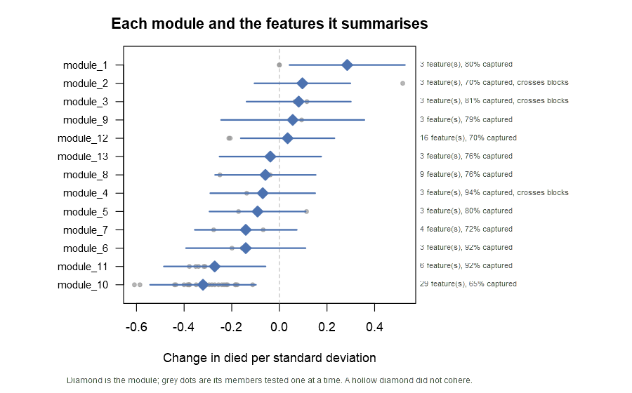

The diamond is the group taken as one thing; the grey dots are its members tested one at a time. Dots scattered on both sides of zero mean the group is averaging over variables that disagree.

module_10 — 29 variables

100% nutrition

A single summary of this group captures **65%** of how its members vary.

Taken as one thing, it shows no relationship with died (FDR 0.061).

Members: DR1TKCAL, DR1TCARB, DR1TP183, DR1TNIAC, DR1TM181, DR1TTFAT, DR1TSFAT, DR1TMFAT, …

module_12 — 16 variables

100% nutrition

A single summary of this group captures **70%** of how its members vary.

Taken as one thing, it shows no relationship with died (FDR 0.73).

Members: COPPER_mg, VITAMIN_B_12_mcg, VITAMIN_A_IU, FOLIC_ACID_mcg, MAGNESIUM_mg, VITAMIN_B_6_mg, THIAMIN_mg, RIBOFLAVIN_mg, …

module_8 — 9 variables

100% body_measures

A single summary of this group captures **76%** of how its members vary.

Taken as one thing, it shows no relationship with died (FDR 0.73).

Members: BMXTHICR, BMXCALF, BMXWAIST, BMXTRI, DXXTRFAT, BMXSUB, DXDTOFAT, BMXWT, …

module_11 — 6 variables

100% nutrition

A single summary of this group captures **92%** of how its members vary.

Taken as one thing, it shows no relationship with died (FDR 0.082).

Members: DR1TS100, DR1TS080, DR1TS140, DR1TS060, DR1TS040, DR1TS120

module_7 — 4 variables

100% body_measures

A single summary of this group captures **72%** of how its members vary.

Taken as one thing, it shows no relationship with died (FDR 0.64).

Members: DXXPEBMD, DXDTOBMD, DXXHEBMD, DXXLSBMD

module_1 — 3 variables

100% biochemistry

A single summary of this group captures **80%** of how its members vary.

Taken as one thing, it shows no relationship with died (FDR 0.092).

Members: LBXHCY, LBXSCRINV, LBXSCR

module_2 — 3 variablesspans several kinds of measurement

67% biochemistry, 33% disease_history

A single summary of this group captures **70%** of how its members vary.

Taken as one thing, it shows no relationship with died (FDR 0.69).

Members: LBXGH, LBXSGL, any_diabetes

module_3 — 3 variablesspans several kinds of measurement

67% biochemistry, 33% nutrition

A single summary of this group captures **81%** of how its members vary.

Taken as one thing, it shows no relationship with died (FDR 0.73).

Members: LBXTC, LBXSCH, LBXVIE

module_4 — 3 variablesspans several kinds of measurement

67% biochemistry, 33% nutrition

A single summary of this group captures **94%** of how its members vary.

Taken as one thing, it shows no relationship with died (FDR 0.73).

Members: LBXSIR, LBDPCT, LBXIRN

module_5 — 3 variables

100% blood

A single summary of this group captures **80%** of how its members vary.

Taken as one thing, it shows no relationship with died (FDR 0.69).

Members: LBXLYPCT, LBDLYMNO, LBXNEPCT

module_6 — 3 variables

100% blood

A single summary of this group captures **92%** of how its members vary.

Taken as one thing, it shows no relationship with died (FDR 0.69).

Members: LBXRBCSI, LBXHGB, LBXHCT

module_9 — 3 variables

100% body_measures

A single summary of this group captures **79%** of how its members vary.

Taken as one thing, it shows no relationship with died (FDR 0.73).

Members: BMXLEG, DXDTOLE, BMXHT

module_13 — 3 variables

100% nutrition

A single summary of this group captures **76%** of how its members vary.

Taken as one thing, it shows no relationship with died (FDR 0.73).

Members: DR1TP225, DR1TP205, DR1TP184

#### These are not extra evidence

A group and the variables inside it are the same measurements at two resolutions. If a group and its members both appear in this report they agree because they are made of each other, and neither one confirms the other. Count the finding once.

Groups were formed by clustering variables on how strongly they move together, at a correlation of 0.50 or more. Variables that move independently were left alone.

## Would this repeat?

The findings above come from the particular people who ended up in this study. To see how much that mattered, the entire analysis was run again on **50** resamples of the same data. What came back was **a substantially different list**.

Reported here

181

Recur reliably

121

in 50% of resamples or more

In both

94

Overlap

45%

of the two lists combined

Each resample produced between 112 and 248 relationships, against the 181 reported here.

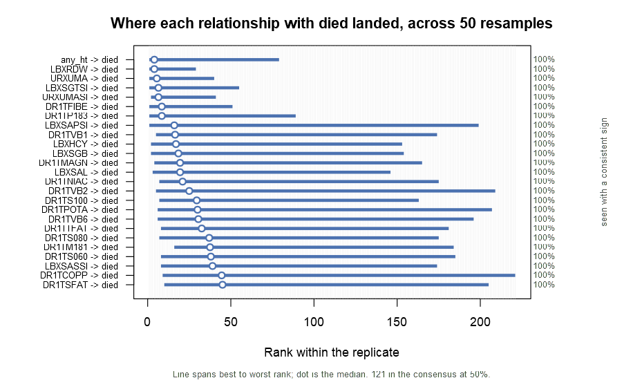

Each line runs from the best to the worst position a relationship reached across the resamples, with a dot at its usual position. A short line on the left would have been reported whoever was sampled. A long line means its place in this report depended on who was.

### Reported here, but rarely came back

These made this report and then failed to reappear in most resamples. Treat them as the weakest thing in it.

- LBXSCRINV → LBXSCR
- LBXGH → LBXSGL
- LBXHCY → LBXSCRINV
- LBXSBU → LBXSOSSI
- LBXSCRINV → LBXSBU
- DXXPEBMD → DXDTOBMD
- LBXGH → any_diabetes
- DXXPEBMD → BMXTHICR
- LBXSGTSI → LBXSAPSI
- LBXSCR → LBXSUA
- LBXHCY → any_ht
- LBXHCY → LBXMMA
- LBXSGTSI → LBXSUA
- LBXSCR → DXDTOBMD
- died → URXUMA
- and 72 more

### Came back reliably, but are not in this report

The opposite problem, and the one a reader cannot discover any other way: these recur across resamples but happened not to clear the threshold in the sample that was collected.

- LBXRDW → died
- URXUMA → died
- LBXSGTSI → died
- URXUMASI → died
- LBXSAL → died
- cad → died
- LBXSBU → died
- DXXPEBMD → died
- LBXSCRINV → died
- LBXVIA → died
- LBXRBF → died
- BMXTHICR → died
- LBXSC3SI → died
- BMXLEG → died
- MDIS → died
- and 12 more

#### What this does and does not tell you

A resample draws from the people who were actually measured, so this says how much the picture depends on which of them ended up in the study. It is not evidence that any relationship is real.

A variable with no connection to the outcome that happens to track it in this sample will track it in almost every resample of that sample too, and will look perfectly stable here. The question of whether these relationships exceed what the same analysis finds on noise is a different one, answered by null calibration at `effort = "thorough"`.

## The overall picture

All relationships together form a map. Variables that connect to many others are shown as hubs; variables that sit between two different kinds of measurement are shown as bridges.

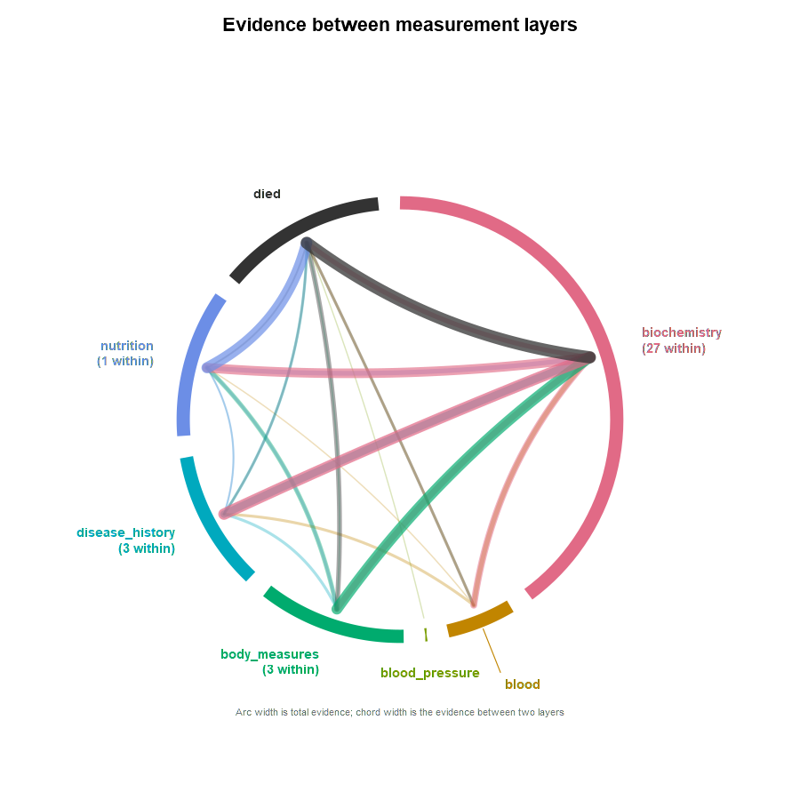

Each arc is one kind of measurement, sized by how much of the evidence it carries. Each ribbon is the evidence running between two of them.

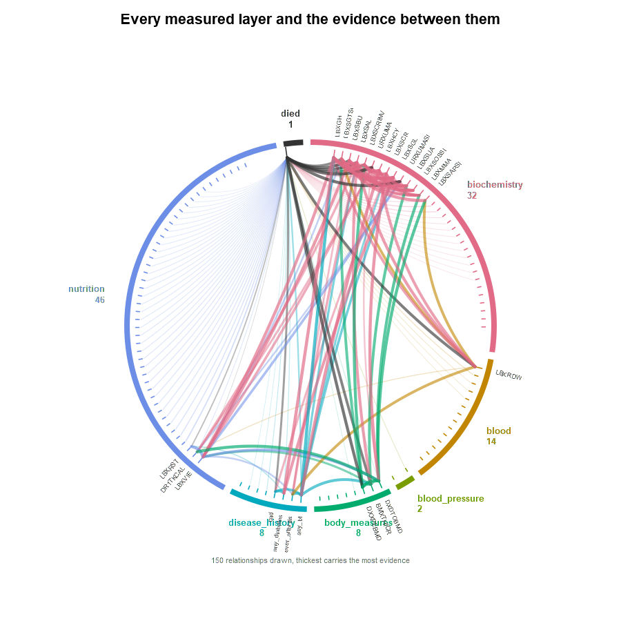

The same picture with every individual variable shown as a tick inside its arc, and every relationship as a thread. Thicker threads carry more evidence.

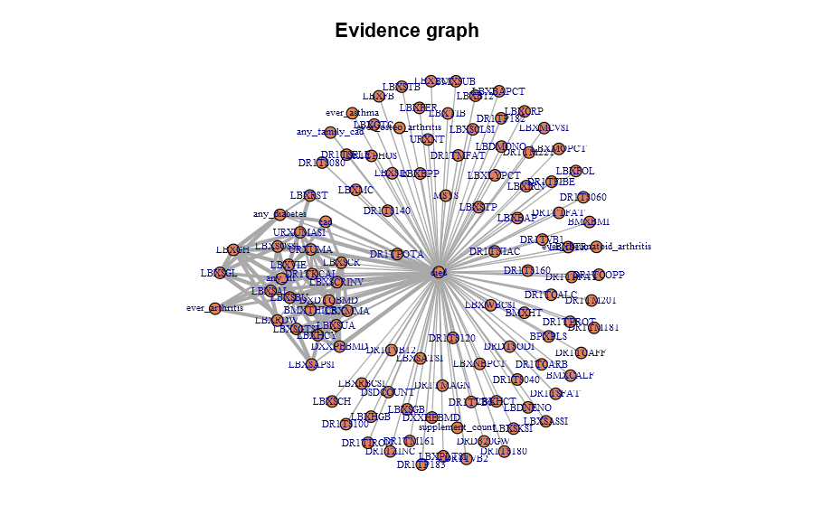

Every arrow is a relationship. Thicker arrows carry more evidence.

#### Hubs

Connected to many other variables, so a change here is likely to be felt widely.

LBXVIELBXSGTSIany_htDXDTOBMDLBXGHLBXHCYLBXSBULBXSCR

#### Bridges

Sit between two different kinds of measurement and link them together.

LBXGHLBXHCYLBXSCRdiedany_htDXDTOBMDLBXSBULBXSAL

#### Associated with a higher outcome

When these go up, the outcome tends to go up.

any_htLBXHCYLBXSTPLBXBAPany_diabetesLBXWBCSILBXSAPSILBXSGB

#### Associated with a lower outcome

When these go up, the outcome tends to go down.

DR1TS120DR1TFIBEDR1TCALCDR1TVB1DR1TMAGNany_family_cadDR1TP183DR1TNIAC

### Which layer carries the result

A relationship between two layers belongs to both, so its weight is split between them. These add to 100%.

biochemistry

56.2%

40 variables · 89 relationships · 24 reaching the outcome

nutrition

13.6%

73 variables · 61 relationships · 44 reaching the outcome

body_measures

12.9%

17 variables · 24 relationships · 6 reaching the outcome

disease_history

11.7%

8 variables · 24 relationships · 6 reaching the outcome

blood

5.5%

20 variables · 21 relationships · 13 reaching the outcome

blood_pressure

0.2%

3 variables · 2 relationships · 2 reaching the outcome

### What runs between the layers

Relationships inside a single layer are left out here: two proteins moving together usually reflects them being part of the same process, not one acting on the other.

| From | To | Relationships | Average evidence | Strongest kind of evidence |
| --- | --- | --- | --- | --- |
| outcome | biochemistry | 6 | 54.69 | associational |
| biochemistry | disease_history | 6 | 50.70 | associational |
| nutrition | outcome | 44 | 6.72 | associational |
| body_measures | biochemistry | 5 | 56.92 | associational |
| biochemistry | nutrition | 5 | 50.24 | associational |
| disease_history | biochemistry | 4 | 46.95 | associational |
| biochemistry | blood | 3 | 56.18 | associational |
| biochemistry | body_measures | 4 | 37.02 | associational |
| outcome | body_measures | 2 | 55.91 | associational |
| biochemistry | outcome | 24 | 4.62 | associational |
| nutrition | biochemistry | 3 | 35.98 | associational |
| blood | biochemistry | 2 | 52.96 | associational |
| body_measures | nutrition | 2 | 50.58 | associational |
| outcome | blood | 1 | 55.92 | associational |
| disease_history | outcome | 6 | 9.22 | associational |
| disease_history | body_measures | 1 | 55.21 | associational |
| blood | disease_history | 1 | 53.55 | associational |
| nutrition | body_measures | 1 | 52.67 | associational |
| blood | outcome | 13 | 3.25 | associational |
| outcome | disease_history | 1 | 37.32 | associational |
| nutrition | disease_history | 1 | 31.13 | associational |
| outcome | nutrition | 2 | 11.53 | associational |
| disease_history | nutrition | 1 | 15.64 | associational |
| body_measures | outcome | 6 | 2.48 | associational |
| blood | nutrition | 1 | 10.46 | associational |
| blood_pressure | outcome | 2 | 4.13 | associational |

### The groups it found

The map splits into clusters of variables more connected to each other than to the rest. A cluster spanning several layers is the interesting case; one confined to a single layer usually reflects how that layer was measured.

| Variables | Made up of | Reading |
| --- | --- | --- |
| 86 | 50% nutrition, 21% biochemistry, 15% blood, 6% body_measures, 5% disease_history, 2% blood_pressure, 1% outcome | mixed layers |
| 25 | 56% biochemistry, 16% disease_history, 12% body_measures, 12% nutrition, 4% blood | mixed layers |

## Which variables matter most

Several methods rank the variables by how useful they are. Because each method produces numbers on its own scale, the rankings are combined rather than the raw values. A value near 1 means the variable came out near the top in most methods.

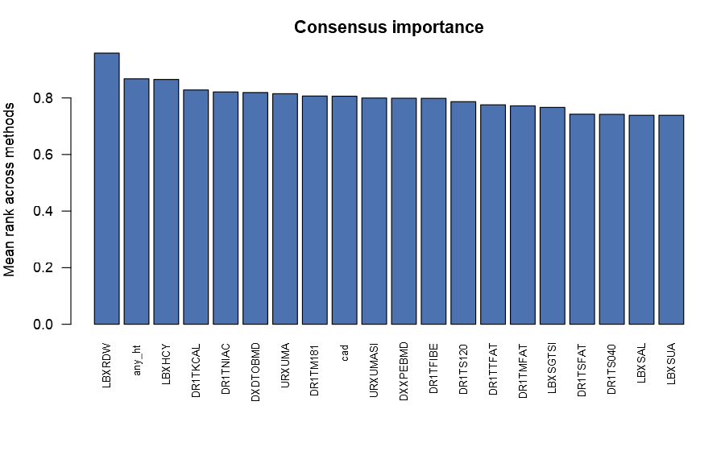

| Variable | Measurement type | Methods that ranked it | Combined ranking |
| --- | --- | --- | --- |
| LBXRDW | blood | 3 | 0.9582 |
| any_ht | disease_history | 4 | 0.8676 |
| LBXHCY | biochemistry | 5 | 0.8652 |
| DR1TKCAL | nutrition | 2 | 0.8281 |
| DR1TNIAC | nutrition | 2 | 0.8211 |
| DXDTOBMD | body_measures | 2 | 0.8189 |
| URXUMA | biochemistry | 4 | 0.8148 |
| DR1TM181 | nutrition | 2 | 0.8067 |
| cad | disease_history | 3 | 0.8060 |
| URXUMASI | biochemistry | 4 | 0.7997 |
| DXXPEBMD | body_measures | 3 | 0.7989 |
| DR1TFIBE | nutrition | 2 | 0.7985 |
| DR1TS120 | nutrition | 1 | 0.7867 |
| DR1TTFAT | nutrition | 2 | 0.7756 |
| DR1TMFAT | nutrition | 2 | 0.7719 |
| LBXSGTSI | biochemistry | 3 | 0.7665 |
| DR1TSFAT | nutrition | 2 | 0.7426 |
| DR1TS040 | nutrition | 2 | 0.7419 |
| LBXSAL | biochemistry | 3 | 0.7385 |
| LBXSUA | biochemistry | 2 | 0.7385 |

## How the analysis was done

The following methods were run. Each one looks at the data differently, which is why agreement between them is reported.

| Method | Relationships reported |
| --- | --- |
| Adjusted association | 150 |
| Conditional independence | 0 |
| Bootstrap mediation | 0 |
| Elastic net selection | 22 |
| Random forest importance | 135 |
| Bayesian network structure | 88 |
| Structural equation model | 8 |

### Not run

- survival: skipped, not applicable to a cross-sectional design.
- longitudinal: skipped, not applicable to a cross-sectional design.

### Study design

The data was treated as **cross-sectional**.

## Where these numbers come from

Every quantity in this report is listed here with how it was produced. If a number anywhere in the document is unclear, it is explained below.

### The path from your data to these results

[output not shown]

### The methods behind these results

Each looks at the data differently, which is the point: agreement between methods that share no assumptions says more than one method repeated. Each carries a level describing what kind of claim it can support, and agreement is weighted by that level rather than counted.

**Bayesian network structure**level 2, associational

Searches for a network of arrows that explains the observed pattern of correlations with as few connections as possible.

**What it cannot tell you.** Several different arrangements of arrows explain the same data equally well, so the direction it picks is often one of many that fit.

**Adjusted association**level 2, associational

Fits a straight line between the variable and the outcome, after subtracting the effect of any factors you asked it to account for.

**What it cannot tell you.** It cannot tell which one came first, and it can only account for factors that were actually measured.

**Elastic net selection**level 1, predictive

Fits every variable at once and shrinks the useless ones to exactly zero, so what survives is a short list that predicts the outcome together.

**What it cannot tell you.** When two variables carry the same information it keeps one and drops the other, so being dropped is not evidence of having no effect.

**Random forest importance**level 1, predictive

Builds hundreds of decision trees and measures how much worse the predictions get when one variable is scrambled. A big drop means the variable carried real information.

**What it cannot tell you.** It measures usefulness for prediction, not the size or the direction of an effect. Something downstream of the outcome predicts it beautifully.

**Structural equation model**level 2, associational

Fits all the candidate variables against the outcome simultaneously, so each estimate is adjusted for the others.

**What it cannot tell you.** The structure it fits was written automatically, not derived from biology. It is a multivariable regression, despite the name.

### Every quantity, explained

**Evidence score**0 to 100

Size, Precision and Agreement multiplied together, then scaled. All three must be reasonable for the score to be high: a large effect measured badly scores low, and so does a tiny effect measured perfectly.

**Careful.** It is a summary of how well supported a relationship is, not of how important it is biologically.

**Size**0 to 1

How large the relationship is, put on a common scale so that methods measuring different things can be averaged.

**Careful.** A big number here means the variables move together a lot, not that one causes the other.

**Precision**0 to 1

How tightly the number was pinned down. Built from the number of samples, the width of the confidence interval, and the significance after correcting for how many things were tested.

**Careful.** High precision on a biased estimate just means confidently wrong.

**Agreement**0 to 1

How many of the methods that looked at this relationship saw it in the same direction, weighted so that stronger kinds of evidence count for more than weaker ones.

**Careful.** Methods sharing the same blind spot agree with each other. This measures stability, not truth.

**Estimate**any number

The size of the relationship in the units that particular method works in. A Cox model reports it on a log scale, a random forest reports a drop in prediction quality: they are not comparable across rows.

**Careful.** Compare estimates within a method, never between methods.

**95% CI**a range

The range of values compatible with the data. Narrow means well determined.

**Careful.** If the range crosses zero, the data does not exclude there being no relationship at all.

**p-value**0 to 1

How surprising this result would be if there were really no relationship. Small means surprising.

**Careful.** It says nothing about how big or how important the relationship is.

**FDR**0 to 1

The p-value corrected for having tested many things at once. Test a thousand variables and fifty will look significant by luck; this accounts for that.

**Careful.** Always read the FDR rather than the raw p-value here.

**E-value**1 upwards

How strong a hidden factor would have to be, on both the variable and the outcome, to explain the whole relationship away. Near 1 means a trivial one would do it.

**Careful.** It does not say a hidden factor exists. It says how much would be needed.

**Recovered in**a percentage

The analysis was repeated on many random re-samples of the same people. This is how often the relationship survived.

**Careful.** A relationship that disappears in half the resamples is fragile even if its score is high.

**Direction confidence**0.5 to 1

When methods disagree about which way the arrow points, how one-sided that disagreement was. 0.5 means it was a coin flip.

**Careful.** Only measurement order settles direction. Everything else is inference.

**n**a count

How many samples that particular method actually used, after dropping any with missing values.

**Careful.** Different rows can rest on different numbers of people.

### Where to find the raw numbers

Nothing here is hidden. In R, on the object this report was built from:

```
result$evidence[[1]]$contributions   # what every method said
result$effects                       # the same, for every relationship
result$tables$evidence               # the merged and scored relationships
result$diagnostics                   # model fit, resampling, calibration
explain(result, "NAME")              # everything known about one variable
```

## What the analysis is based on

Samples analysed

687

Samples set aside

1113

not measured in every block

Variables examined

150

of 161 available

Only samples present in every block can be compared across blocks, so 1113 were set aside.

#### Not everything was examined

There were too many variables to test every possible pair, so 150 were carried forward on the strength of their relationship with the outcome. The remaining 11 were not examined for indirect roles and could still matter.

## Limitations

### Glossary

**Outcome**

The thing the analysis is trying to explain.

**Variable**

Anything that was measured.

**Relationship**

Two variables that change together in a way unlikely to be chance alone.

**Evidence score**

A 0-100 summary combining size, precision and agreement.

**Adjusted**

Other known factors were subtracted out before measuring the relationship.

**Confounder**

Something not measured that drives two variables at once, making them look related.

**Mediator**

A variable that sits between a cause and its outcome.

**Hub**

A variable connected to many others.

[figure not shown]